# h-2.2

```python
#load data

import pandas as pd

# load sample csv
df_gss_sample = pd.read_csv('data.copy/gss_sample.csv', index_col=0, low_memory=False, encoding='utf8')

# load rows counts of full data
gss_full_row_counts = pd.read_csv('data.copy/gss_full_row_counts.csv', index_col=0, low_memory=False, encoding='utf8')

# load years per variable data
gss_years_per_var = pd.read_csv('meta.copy/gss_data_years_per_var.csv', index_col=0, low_memory=False, encoding='utf8')

# load data dictionary
gss_data_dictionary =  pd.read_csv('meta.copy/gss_data_dictionary.csv', index_col=0, low_memory=False, encoding='latin1')
```

Question 1

Working with df_gss_sample, create a variable called mycols that is a list of ten (10) column names that are related to one another in some way. Create a new variable called df_gss_sample_ten_cols that contains only the ten (10) columns in mycols. In a markdown cell below this question, explain how your variables are related to one another. Hint: to find related variables, look at the variable names, the 'var_doc_label' column in gss_data_dictionary and/or the GSS Data Explorer at https://gssdataexplorer.norc.org/.

```python
mycols = ['relig', 'denom', 'attend', 'reliten', 'postlife', 'jew', 'spkmslm','maattend', 'paattend', 'spattend']
df_gss_sample_10_cols = df_gss_sample[mycols]
```

The variables I chose are all related to religion. I chose them by filtering my search on GSS Data Explorer by religion.

Question 2

In a markdown cell below this question, address the following:

How does gss_sample relate to gss_full_row_counts? If we assume gss_sample is a sample of a larger dataset of GSS data, why would we want some information about the full rows counts from the dataset? Generally speaking, what information is contained in the gss_years_per_var and gss_data_dictionary DataFrames? How can we use these sources to better understand our sample?

The gss_full_row_counts likely contains the total number of surveys/responses for that year. Assuming gss_sample is a sample, we might want to know where the responses in our sample are coming from within the full dataset and it is interesting to know how much of the data is in our sample dataset. It can act as a frame of reference for the scope of our sample dataset. Having the full data count can also help identify any missing data in our sample.

It seems like the gss_years_per_var dataframe shows which years each variable were included in the survey and the gss_data_dictionary likely defines what each variable represents. I honestly couldn't open the gss_data_dictionary file because it kept saying there was an encoding error and I couldn't figure out how to work around it.

Question 3

In a code cell below this question, use the `value_counts` method to display a count for each unique value found in the `zodiac` column of `df_gss_sample`. **Display the result as a `DataFrame`**.

```python
zodiac_count = df_gss_sample['zodiac'].value_counts()
df_zodiac_count = pd.DataFrame({'Zodiac Sign': zodiac_count.index, 'Count': zodiac_count.values})
df_zodiac_count
```

|  | Zodiac Sign | Count |
| --- | --- | --- |
| 0 | 6.0 | 297 |
| 1 | 5.0 | 288 |
| 2 | 12.0 | 285 |
| 3 | 2.0 | 281 |
| 4 | 11.0 | 273 |
| 5 | 7.0 | 266 |
| 6 | 4.0 | 261 |
| 7 | 10.0 | 256 |
| 8 | 8.0 | 248 |
| 9 | 1.0 | 238 |
| 10 | 9.0 | 237 |
| 11 | 3.0 | 236 |

Question 4

In a code cell below this question, display a scatter plot depicting the `realinc` variable on one axis and the respondents occupational prestige score based on the 2010 Census occupation classification.

**Hint:** Pandas has some simple plotting options built into it, and the Seaborn library is designed to accept a pandas DataFrame as an input, sort of like (but not as good as) ggplot in R. Here are some resources on Pandas and Seaborn plots:

- Built-in plots: https://pandas.pydata.org/docs/user_guide/10min.html#plotting
- Seaborn scatter plot: https://seaborn.pydata.org/generated/seaborn.scatterplot.html

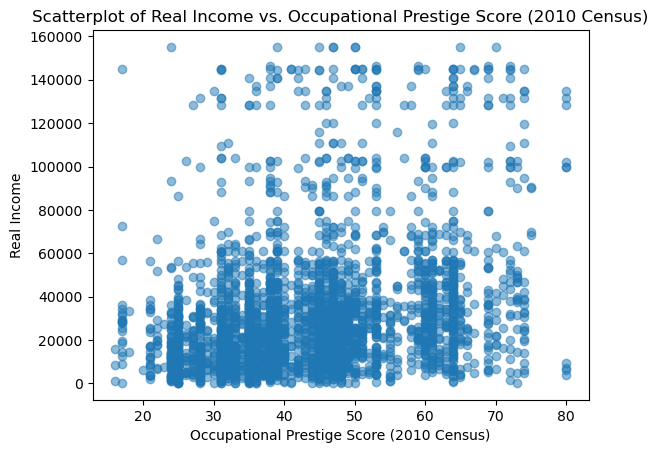

```python
import matplotlib.pyplot as plt
plt.scatter(df_gss_sample['prestg10'], df_gss_sample['realinc'], alpha = 0.5)
plt.xlabel('Occupational Prestige Score (2010 Census)')
plt.ylabel('Real Income')
plt.title('Scatterplot of Real Income vs. Occupational Prestige Score (2010 Census)')
```